# Exploring Missing Data, Correlations, and Comparisons with visdat

Salome Shunamon

February 12, 2026

## About the Dataset: QatarCars

For this exploration, we’re analyzing the quatarcars.csv dataset, which contains specifications for premium vehicles in Qatar in 2025. This dataset mirror similar columns available in the mrcars dataset, but uses current pricing, metric measurements, and is not US-centric.

Author Paul Musgrave [aut, cre, cph] (ORCID: https://orcid.org/0000-0002-8984-4992), Andrew Heiss [aut] (ORCID: https://orcid.org/0000-0002-3948-3914) Maintainer Paul Musgrave rpm47@georgetown.edu Qatarcars Repository CRAN License CC BY 4.0 Date/Publication 2025-10-16 12:00:02 UTC

```r
# Load any datasets you may need
# ?read.csv
cars <- read.csv("qatarcars.csv", stringsAsFactors = FALSE)
```

## What is Visdat?

The visdat package, created by Nicholas Tierney, provides lightweight tools for visualizing entire data frames at once. While similar to ggplot2, visdat is specifically designed for data discovery rather than data presentation. It helps you quickly identify missing values, variable types, and relationships across your entire dataset and create preliminary exploratory data visualizations to identify problems or unexpected features. It’s also useful for preliminary data exploration, such as revealing gaps in the data that may inspire new or different paths of inquiry.

### vis_miss()

We can see from this chart that the qatarcars dataset is missing 0.6% of it’s data, mostly in the economy variable.

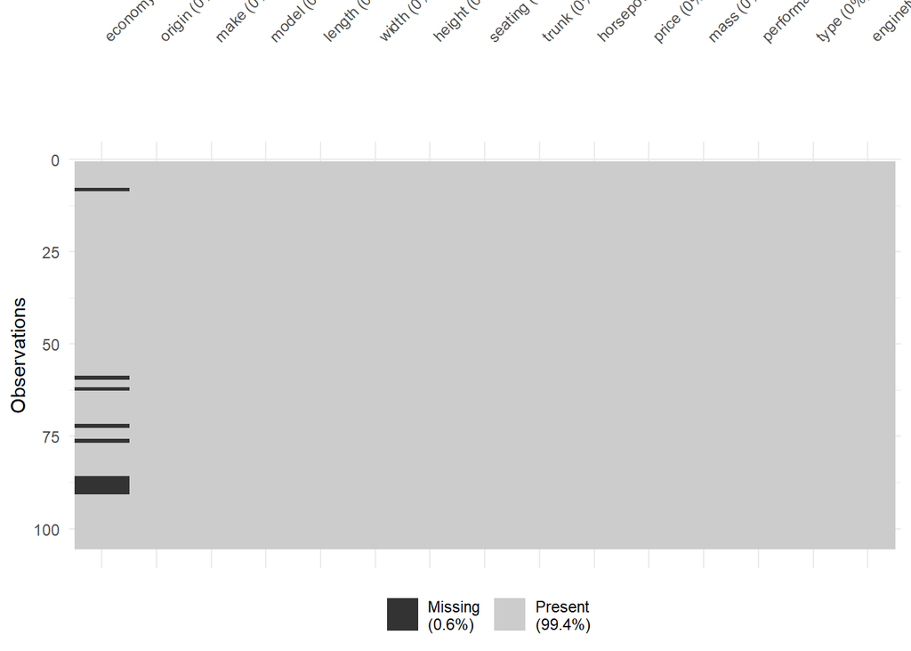

```r
vis_miss(cars, sort_miss = TRUE)
```

Zooming in, the economy variable of our qatarcars dataset is missing 9.5% of values.

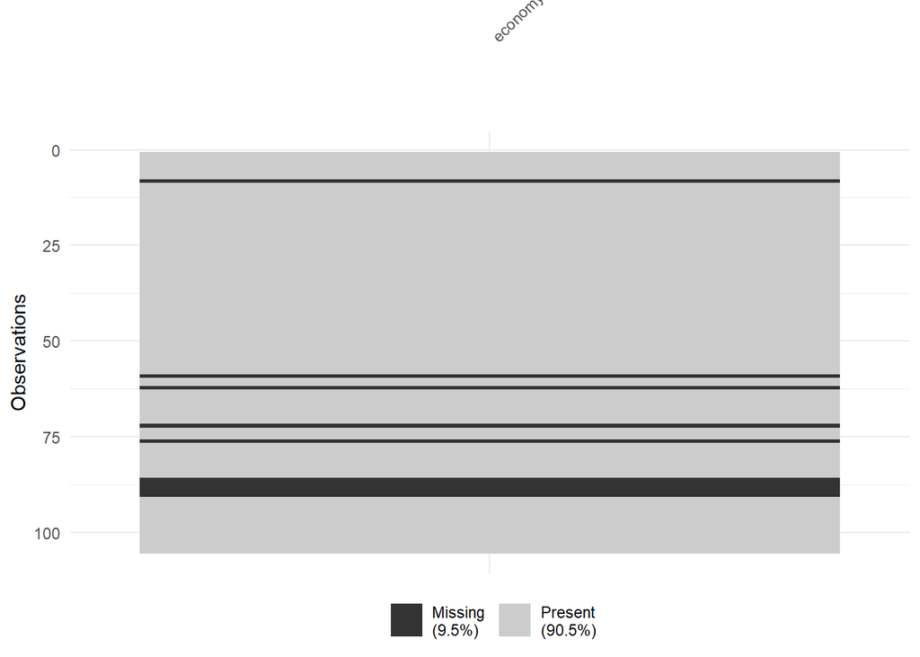

```r
cars_eco <- data.frame(economy = cars$economy)
vis_miss(cars_eco)
```

Here we can can cluster the missing data to get a better visual of how much 9.5% represents.

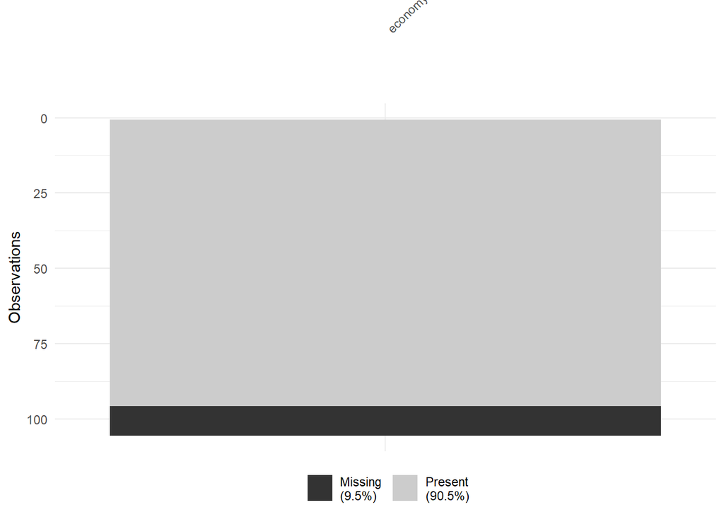

```r
vis_miss(cars_eco, cluster = TRUE, warn_large_data = FALSE)
```

### vis_compare()

The vis_compare function lets you to visualize the differences between two data frames of identical dimensions by creating a comparison plot that highlights exactly where and how the datasets diverge. This function is essential for validating data cleaning operations. When you run vis_compare on an original and modified dataset, cells that are identical appear in one color while cells that differ appear in a contrasting color giving you an immediate visual audit of every change made across your entire data frame without requiring manual inspection.

When we run vis_compare(cars, cars_modified), we are seeing a visual comparison between the original cars dataset and the modified version where we changed the price.

[figure not shown]

```r
cars_modified <- cars
cars_modified[1, "price"] <- 170000
vis_compare(cars, cars_modified)
```

### vis_cor()

The vis_cor function creates a ggplot2-based correlation visualization for all numeric variables in your dataset, transforming the usual correlation matrix into a color-coded heatmap that makes relationships easy to see and visual. Vis_cor uses R’s base cor function and provides flexibility to specify different correlation methods like pearson, kendall, or spearman coefficients. It also has different approaches for handling missing data like the na_action parameter. Vis_cor automatically excludes non-numeric columns and scales the visualization accordingly presenting strong correlations in one color, strong negative correlations in a contrasting color, and weak correlations in neutral colors, which allows us to identify the most significant relationships in the data without writing complex code.

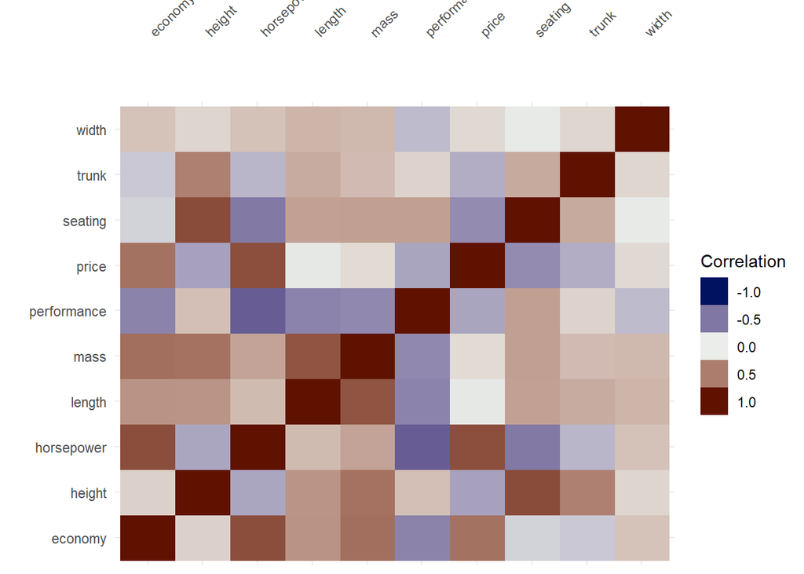

```r
cars_num <- dplyr::select(cars, where(is.numeric))
vis_cor(cars_num)
```

## Reflection

What I found most interesting about visdat package is how it transforms the manual process of data inspection into a visual experience. The vis_miss function revealed the missing economy data in seconds, and I realized that this wasn’t an error but rather a meaningful gap indicating an electric vehicle in a dataset designed for fuel-powered cars.I can see vis_compare being incredibly useful in my future workflow for validating complex data cleaning operations, especially when I need to prove to collaborators or reviewers that my transformations only affected intended cells. The biggest challenge I faced was understanding why vis_cor claims to exclude certain columns but didn’t in actuality, and I had to manually isolate the numeric columns and learn to properly subset my data to include only numeric variables. I still have questions about how vis_compare would perform on extremely large datasets with thousands of rows and whether the visual differentiation would remain useful at scale. Overall, I found this to be an interesting project and it was a lot of fun.

## Sources

- [Visdat on cran.r-project.org](https://cran.r-project.org/web/packages/visdat/index.html)
- [Visdat on cran.r-project.org > using visdat](https://cran.r-project.org/web/packages/visdat/vignettes/using_visdat.html)
- [Visdat official Github Repository](https://github.com/ropensci/visdat)
- [OpenSci Visdat](https://docs.ropensci.org/visdat/)